# Predicting IMDB Ratings of Over 5000 Different Movies

Kaifeng Wang

May 18, 2018

# Introduction

Did you ever wonder which factors played the biggest role in how highly a movie is rated? Especially with the recent trend of superhero movies, it’s easy to believe that movies only require a high budget or a popular staff to succeed at the box office. In this tutorial, I will aim to prove exactly that: given what we know, how reliably can we predict how well a movie will be rated on sites like IMDB? I will walk us through the data acquisition/management, then look at some exploratory data analysis, and finally use machine learning to try and predict imdb ratings.

## Required Packages

I’m using the latest version of RStudio to write my code. If you don’t know what that is, here is where you can download the software and learn more about what it can do: https://www.rstudio.com/  
You’re going to want to install these packages for our program to work:

```r
# Packages we will need
library(broom)     # Data Manipulation
library(tidyverse) # Data manipulation
library(lubridate) # Converting datetime
```

```r
library(dplyr)     # Data manipulation
library(ggplot2)   # graphing
library(ggrepel)   # Visualization
library(randomForest) # Machine learning
```

# Data Curation

The dataset I’m using is a set of over 5000 IMDB movie data scraped from the IMDB website. The data is hosted by @Data-Society at Data.World, which you can download here: https://data.world/data-society/imdb-5000-movie-dataset  
We will then use the read_csv function to read our .csv file into RStudio, and convert it to a useable data frame.

```r
data <- read_csv("movie_metadata.csv")
as_tibble(data)
```

```
## # A tibble: 5,043 x 28
##    color director_name    num_critic_for_rev~ duration director_facebook_~
##    <chr> <chr>                          <int>    <int>               <int>
##  1 Color James Cameron                    723      178                   0
##  2 Color Gore Verbinski                   302      169                 563
##  3 Color Sam Mendes                       602      148                   0
##  4 Color Christopher Nol~                 813      164               22000
##  5 <NA>  Doug Walker                       NA       NA                 131
##  6 Color Andrew Stanton                   462      132                 475
##  7 Color Sam Raimi                        392      156                   0
##  8 Color Nathan Greno                     324      100                  15
##  9 Color Joss Whedon                      635      141                   0
## 10 Color David Yates                      375      153                 282
## # ... with 5,033 more rows, and 23 more variables:
## #   actor_3_facebook_likes <int>, actor_2_name <chr>,
## #   actor_1_facebook_likes <int>, gross <int>, genres <chr>,
## #   actor_1_name <chr>, movie_title <chr>, num_voted_users <int>,
## #   cast_total_facebook_likes <int>, actor_3_name <chr>,
## #   facenumber_in_poster <int>, plot_keywords <chr>,
## #   movie_imdb_link <chr>, num_user_for_reviews <int>, language <chr>,
## #   country <chr>, content_rating <chr>, budget <int>, title_year <int>,
## #   actor_2_facebook_likes <int>, imdb_score <dbl>, aspect_ratio <dbl>,
## #   movie_facebook_likes <int>
```

A lot of columns are cut off here, so let’s try to get some more detail about these attributes:

```r
str(data)
```

```
## Classes 'tbl_df', 'tbl' and 'data.frame':    5043 obs. of  28 variables:
##  $ color                    : chr  "Color" "Color" "Color" "Color" ...
##  $ director_name            : chr  "James Cameron" "Gore Verbinski" "Sam Mendes" "Christopher Nolan" ...
##  $ num_critic_for_reviews   : int  723 302 602 813 NA 462 392 324 635 375 ...
##  $ duration                 : int  178 169 148 164 NA 132 156 100 141 153 ...
##  $ director_facebook_likes  : int  0 563 0 22000 131 475 0 15 0 282 ...
##  $ actor_3_facebook_likes   : int  855 1000 161 23000 NA 530 4000 284 19000 10000 ...
##  $ actor_2_name             : chr  "Joel David Moore" "Orlando Bloom" "Rory Kinnear" "Christian Bale" ...
##  $ actor_1_facebook_likes   : int  1000 40000 11000 27000 131 640 24000 799 26000 25000 ...
##  $ gross                    : int  760505847 309404152 200074175 448130642 NA 73058679 336530303 200807262 458991599 301956980 ...
##  $ genres                   : chr  "Action|Adventure|Fantasy|Sci-Fi" "Action|Adventure|Fantasy" "Action|Adventure|Thriller" "Action|Thriller" ...
##  $ actor_1_name             : chr  "CCH Pounder" "Johnny Depp" "Christoph Waltz" "Tom Hardy" ...
##  $ movie_title              : chr  "Avatar " "Pirates of the Caribbean: At World's End " "Spectre " "The Dark Knight Rises " ...
##  $ num_voted_users          : int  886204 471220 275868 1144337 8 212204 383056 294810 462669 321795 ...
##  $ cast_total_facebook_likes: int  4834 48350 11700 106759 143 1873 46055 2036 92000 58753 ...
##  $ actor_3_name             : chr  "Wes Studi" "Jack Davenport" "Stephanie Sigman" "Joseph Gordon-Levitt" ...
##  $ facenumber_in_poster     : int  0 0 1 0 0 1 0 1 4 3 ...
##  $ plot_keywords            : chr  "avatar|future|marine|native|paraplegic" "goddess|marriage ceremony|marriage proposal|pirate|singapore" "bomb|espionage|sequel|spy|terrorist" "deception|imprisonment|lawlessness|police officer|terrorist plot" ...
##  $ movie_imdb_link          : chr  "http://www.imdb.com/title/tt0499549/?ref_=fn_tt_tt_1" "http://www.imdb.com/title/tt0449088/?ref_=fn_tt_tt_1" "http://www.imdb.com/title/tt2379713/?ref_=fn_tt_tt_1" "http://www.imdb.com/title/tt1345836/?ref_=fn_tt_tt_1" ...
##  $ num_user_for_reviews     : int  3054 1238 994 2701 NA 738 1902 387 1117 973 ...
##  $ language                 : chr  "English" "English" "English" "English" ...
##  $ country                  : chr  "USA" "USA" "UK" "USA" ...
##  $ content_rating           : chr  "PG-13" "PG-13" "PG-13" "PG-13" ...
##  $ budget                   : int  237000000 300000000 245000000 250000000 NA 263700000 258000000 260000000 250000000 250000000 ...
##  $ title_year               : int  2009 2007 2015 2012 NA 2012 2007 2010 2015 2009 ...
##  $ actor_2_facebook_likes   : int  936 5000 393 23000 12 632 11000 553 21000 11000 ...
##  $ imdb_score               : num  7.9 7.1 6.8 8.5 7.1 6.6 6.2 7.8 7.5 7.5 ...
##  $ aspect_ratio             : num  1.78 2.35 2.35 2.35 NA 2.35 2.35 1.85 2.35 2.35 ...
##  $ movie_facebook_likes     : int  33000 0 85000 164000 0 24000 0 29000 118000 10000 ...
##  - attr(*, "problems")=Classes 'tbl_df', 'tbl' and 'data.frame': 4 obs. of  5 variables:
##   ..$ row     : int  2324 2989 3006 3860
##   ..$ col     : chr  "budget" "budget" "budget" "budget"
##   ..$ expected: chr  "an integer" "an integer" "an integer" "an integer"
##   ..$ actual  : chr  "2400000000" "12215500000" "2500000000" "4200000000"
##   ..$ file    : chr  "'movie_metadata.csv'" "'movie_metadata.csv'" "'movie_metadata.csv'" "'movie_metadata.csv'"
##  - attr(*, "spec")=List of 2
##   ..$ cols   :List of 28
##   .. ..$ color                    : list()
##   .. .. ..- attr(*, "class")= chr  "collector_character" "collector"
##   .. ..$ director_name            : list()
```

[output cut: 41 more lines]

```
##   .. ..$ budget                   : list()
##   .. .. ..- attr(*, "class")= chr  "collector_integer" "collector"
##   .. ..$ title_year               : list()
##   .. .. ..- attr(*, "class")= chr  "collector_integer" "collector"
##   .. ..$ actor_2_facebook_likes   : list()
##   .. .. ..- attr(*, "class")= chr  "collector_integer" "collector"
##   .. ..$ imdb_score               : list()
##   .. .. ..- attr(*, "class")= chr  "collector_double" "collector"
##   .. ..$ aspect_ratio             : list()
##   .. .. ..- attr(*, "class")= chr  "collector_double" "collector"
##   .. ..$ movie_facebook_likes     : list()
##   .. .. ..- attr(*, "class")= chr  "collector_integer" "collector"
##   ..$ default: list()
##   .. ..- attr(*, "class")= chr  "collector_guess" "collector"
##   ..- attr(*, "class")= chr "col_spec"
```

We’ve got an idea of what kind of data we’re working with: whether the film is in color, the director’s name, how many likes it got on Facebook, etc. Now let’s try to clean up some of these entries.

## Tidying our Data

We have quite a few missing values in a lot of places, which won’t bode well for our machine learning algorithm.

```r
sapply(data, function(x) sum(is.na(x)))
```

```
##                     color             director_name
##                        19                       104
##    num_critic_for_reviews                  duration
##                        50                        15
##   director_facebook_likes    actor_3_facebook_likes
##                       104                        23
##              actor_2_name    actor_1_facebook_likes
##                        13                         7
##                     gross                    genres
##                       884                         0
##              actor_1_name               movie_title
##                         7                         0
##           num_voted_users cast_total_facebook_likes
##                         0                         0
##              actor_3_name      facenumber_in_poster
##                        23                        13
##             plot_keywords           movie_imdb_link
##                       153                         0
##      num_user_for_reviews                  language
##                        21                        12
##                   country            content_rating
##                         5                       303
##                    budget                title_year
##                       496                       108
##    actor_2_facebook_likes                imdb_score
##                        13                         0
##              aspect_ratio      movie_facebook_likes
##                       329                         0
```

Since this is such a large dataset, omitting these entries is the way to go here. Most entries have more than one missing value, and it would be too difficult to try and fill these in ourselves.

```r
data <- data %>%
  # omit entries containing missing values
  na.omit()
```

There are way too many attributes to make use of in this single tutorial. We’d like to get rid of a lot of these, to make it easier to understand what we’re working with.

```r
data <- data %>%
  select(-plot_keywords) %>%          # Just some keywords about the movie
  select(-country) %>%                # We won't be using Country movie was made in
  select(-actor_2_facebook_likes) %>% # We already have total cast facebook likes, anyway
  select(-actor_3_facebook_likes) %>%
  select(-actor_2_name) %>%           # We won't deal with secondary actors (for now)
  select(-actor_3_name) %>%
  select(-movie_imdb_link) %>%        # Definitely don't need the IMDB link to the movie
  select(-content_rating) %>%         # We won't use the movie's content rating
  select(-num_critic_for_reviews) %>% # Number of user/critic reviewers doesn't pertain to us
  select(-num_user_for_reviews) %>%
  select(-aspect_ratio) %>%           # Don't need the aspect ratio of the movie
  select(-language)                   # We won't do anything concerning the language of the movie
data
```

```
## # A tibble: 3,752 x 16
##    color director_name  duration director_faceboo~ actor_1_faceboo~  gross
##    <chr> <chr>             <int>             <int>            <int>  <int>
##  1 Color James Cameron       178                 0             1000 7.61e8
##  2 Color Gore Verbinski      169               563            40000 3.09e8
##  3 Color Sam Mendes          148                 0            11000 2.00e8
##  4 Color Christopher N~      164             22000            27000 4.48e8
##  5 Color Andrew Stanton      132               475              640 7.31e7
##  6 Color Sam Raimi           156                 0            24000 3.37e8
##  7 Color Nathan Greno        100                15              799 2.01e8
##  8 Color Joss Whedon         141                 0            26000 4.59e8
##  9 Color David Yates         153               282            25000 3.02e8
## 10 Color Zack Snyder         183                 0            15000 3.30e8
## # ... with 3,742 more rows, and 10 more variables: genres <chr>,
## #   actor_1_name <chr>, movie_title <chr>, num_voted_users <int>,
## #   cast_total_facebook_likes <int>, facenumber_in_poster <int>,
## #   budget <int>, title_year <int>, imdb_score <dbl>,
## #   movie_facebook_likes <int>
```

## Adjusting for Inflation

Since our range of movies is quite large, it would be inaccurate to compare movie budgets without adjusting for yearly inflation. I’ve taken another .csv of the monthly Consumer Price Index for All Urban Consumers (CPIAUC) of the past 70 years in America so we can adjust the budget/gross to one year. You can find the dataset from https://fred.stlouisfed.org/series/CPIAUCSL/ and learn more about how the U.S. Bureau of Labor Statistics collects this information.

```r
monthly_inflation <- read_csv("CPIAUCSL.csv")     # Read my .csv dataset
yearly_inflation <- monthly_inflation %>%
  mutate(year = year(monthly_inflation$DATE)) %>% # Convert the date into year
  group_by(year) %>%
  summarize(rate = mean(CPIAUCSL)) %>%            # Get the yearly average rate for each year
  mutate(adjustment = rate[year == 2018] / rate)  # Calculate adjustment relative to 2018
tail(yearly_inflation)                            # Print out the last few years
```

```
## # A tibble: 6 x 3
##    year  rate adjustment
##   <dbl> <dbl>      <dbl>
## 1  2013   233       1.07
## 2  2014   237       1.05
## 3  2015   237       1.05
## 4  2016   240       1.04
## 5  2017   245       1.02
## 6  2018   250       1.00
```

Now we can see the adjustment factor we need to multiply for each year in order to convert it to today’s money. Now, we will append this data to our existing table and calculate the new adjusted budgets.

```r
adj_data <- data %>%
  left_join(yearly_inflation,by=c("title_year"="year")) %>% # Add adjustment to table where years match
  mutate(adj_budget=budget * adjustment) %>%                # Calculate new adjusted budget/gross
  mutate(adj_gross=gross * adjustment) %>%
  select(-budget) %>%                                       # No longer have any need for these columns
  select(-gross)
head(adj_data[,c("title_year","movie_title","adjustment","adj_budget","adj_gross")])
```

```
## # A tibble: 6 x 5
##   title_year movie_title                   adjustment adj_budget adj_gross
##        <dbl> <chr>                              <dbl>      <dbl>     <dbl>
## 1       2009 Avatar                              1.16  275681857 884631494
## 2       2007 Pirates of the Caribbean: At~       1.20  361116622 372436607
## 3       2015 Spectre                             1.05  258017445 210704602
## 4       2012 The Dark Knight Rises               1.09  271776872 487166176
## 5       2012 John Carter                         1.09  286670244  79422637
## 6       2007 Spider-Man 3                        1.20  310560295 405088954
```

## Standardize out Data

The last thing we want to do is to normalize the budgets, to get a better range of data for us to work with and make better comparisons. Standardizing is important to account for large changes in data and center/scale our data to a more flexible range. More information about normalization can be found on this simple wikipedia page: https://en.wikipedia.org/wiki/Normalization_(statistics)

```r
final_data <- adj_data %>%
  mutate(std_budget = (adj_budget - mean(adj_budget,na.rm=T))/sd(adj_budget,na.rm=T)) %>% # Calculate standardized budget/gross
  mutate(std_gross = (adj_gross - mean(adj_gross,na.rm=T)) / sd(adj_gross,na.rm=T)) %>%
  select(-adj_budget) %>% # remove unneeded columns
  select(-adj_gross) %>%
  select(-adjustment)
head(final_data[,c("movie_title","std_budget","std_gross","director_name")])
```

```
## # A tibble: 6 x 4
##   movie_title                        std_budget std_gross director_name
##   <chr>                                   <dbl>     <dbl> <chr>
## 1 Avatar                                   2.58    7.20   James Cameron
## 2 Pirates of the Caribbean: At Worl~       3.58    2.64   Gore Verbinski
## 3 Spectre                                  2.38    1.20   Sam Mendes
## 4 The Dark Knight Rises                    2.54    3.66   Christopher Nol~
## 5 John Carter                              2.71    0.0314 Andrew Stanton
## 6 Spider-Man 3                             2.99    2.93   Sam Raimi
```

# Exploratory Data Analysis

Now that we’ve cleaned up our data a little, we can now start doing some analysis. This will allow us to see some obvious trends (or lack of) and get a better sense of what’s most important when gauging how well a movie will fare.

# Data over time

Let’s look at the distribution of movie ratings over time to see if there are any correlations between rating and year the movie was released. I used a violin plot to show the distributions of data, which in this case is far more interesting than most other data visualizations. You can read up more on violin plots here: https://www.r-graph-gallery.com/violin-plot/

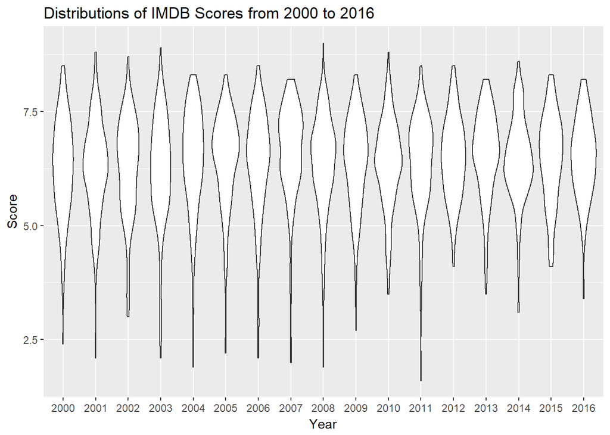

```r
final_data %>%
  filter(title_year >= 2000 & title_year <= 2016) %>%
  ggplot(aes(x=factor(title_year),y=imdb_score)) +
  geom_violin() +
  labs(title="Distributions of IMDB Scores from 2000 to 2016",
    x = "Year",
    y = "Score")
```

# Face Number

An interesting subject that indeed garnered interest concerning this dataset was whether the number of faces on a poster affected how well the movie did. This could be explained by many factors, such as seeing one’s favorite actor on the cover. I constructed a mosaic plot by dividing score and face numbers into 3 categories each, and visualizing the distributions of each one compared to each other. More on mosaic plots can be read here: https://www.tutorialgateway.org/mosaic-plot-in-r/

```r
# I grouped IMDB into 3 categories: great, average, and bad
final_data$rating[final_data$imdb_score >= 8] <- "great"
final_data$rating[final_data$imdb_score >= 5 & final_data$imdb_score < 8] <- "average"
final_data$rating[final_data$imdb_score < 5] <- "bad"

# I grouped number of faces into 3 categories as well: None, some, and many
final_data$facenumberD[final_data$facenumber_in_poster == 0] <- "none"
```

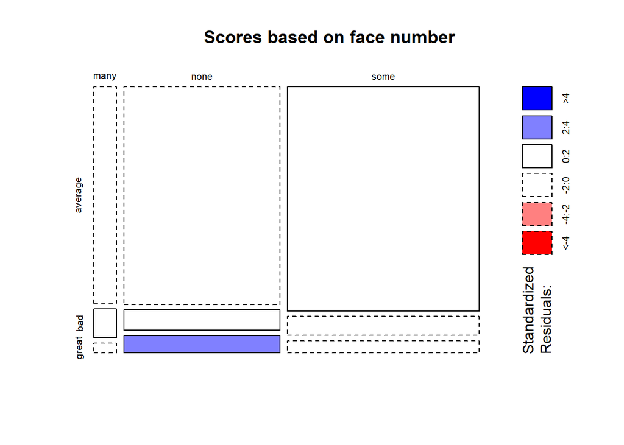

```r
final_data$facenumberD[final_data$facenumber_in_poster > 0 & final_data$facenumber_in_poster <= 5] <- "some"
final_data$facenumberD[final_data$facenumber_in_poster >= 5] <- "many"

mosaicplot(table(final_data$facenumberD,final_data$rating), main="Scores based on face number", shade=TRUE)
```

Again, we see that not too much variation exists among scores solely on face number. We have confirmed that most scores are distributed near the “average” side of data. These graphs are starting to tell us that maybe huge trends in IMDB ratings are pretty uncommon, since we tend to score things all the same on average.

# Scores vs Money

Let’s look at how budget fares in predicting imdb score. We’ll use our standardized budget values and make a scatter plot to see the trend of scores on increasing budget sizes. Here, I took the log of the budget because even still, the range of budgets was quite high and needed to be toned down a little.

[figure not shown]

```r
final_data %>%
  ggplot(aes(x=log(std_budget),y=imdb_score)) +
  geom_point() +
  geom_smooth(method=lm, fill=NA) +
  labs(title="Distributions of IMDB Scores Based on Budget",
    x = "Standardized Budget",
    y = "Score")
```

There’s a slight trend - As budget increases, so does score, which intuitively makes sense. We’ve learned that we’re probably not going to see drastic correlations between many of these factors, but this indeed shows us exactly what we were hoping to expect. We also can see that in fact, some of the higher scoring movies are far from the most expensive ones, which says a lot about how much can be done without expensive machinery, props, actors, etc.

# Actors

Another fun factor to look at is how each actor fares against the IMDB rating system. I’ve only taken some of the more well-known actors on facebook, just to unclutter the data a little and perhaps get a better reading. We’ll be able to see the average IMDB score each actor gets, and the distribution of these scores among the main actors. In another project, maybe we could look into how this adds up when including more actors from the same movie. Once again, I took the log of facebook likes beause the range was too large.

```r
parsed <- final_data %>%
  # Only actors with more than 12000 likes (upper quartile range)
  filter(actor_1_facebook_likes >= 12000) %>%
  group_by(actor_1_name) %>%
  # Compute the mean score of actors
  summarise(mean_score=mean(imdb_score)) %>%
  # Get our old attributes back from the previous table
  inner_join(final_data, actor_1_name=adj_data$actor_1_name) %>%
  # Remove duplicate entries as a result of joining the table
  distinct(actor_1_name, .keep_all = T) %>%
  # Compute an outlier who has an exceedingly good (or bad) score, or one with a significant number of likes
  mutate(outlier=ifelse(mean_score > 7.5 | mean_score < 5 | actor_1_facebook_likes > 300000, TRUE, FALSE))
```

[figure not shown]

```r
parsed %>%
  ggplot(aes(x=log(actor_1_facebook_likes),y=mean_score,label=actor_1_name)) +
    # Assign a color based on whether they're an outlier or not
    geom_point(color = ifelse(parsed$outlier, "red", "blue"), size = 3) +
    # Only label those who are outliers
    geom_label_repel(data = subset(parsed, outlier==TRUE)) +
    labs(title="Average IMDB Scores for Main Actors of Various Movies",
      x = "# of Facebook Likes",
      y = "Score")
```

On average, the actors seem to be well centered around the 6-7 mark. What’s interesting is that the more facebook likes, the lower the average rating it seems. It also seems that infamously poor-rated actors maybe be a good indicator of whether the movie will fare poorly or not.

## Directors

Let’s look at directors in the same way we did actors. We’ll group them based on how popular they are on facebook as well, so that we can see if more reknowned directors might produce better movies. I used boxplots to visualize the correlation between these too, because it will deliver helpful statistics about the median and upper/lower quartiles. If you’ve forgotten what a box plot is, you can see a description here: https://www.r-graph-gallery.com/boxplot/

[figure not shown]

```r
parsed <- final_data %>%
  group_by(director_name) %>%
  # Get the mean IMDB score of each director
  summarise(mean_score = mean(imdb_score),director_facebook_likes=mean(director_facebook_likes)) %>%
  # Compute whether a director is popular based on the # of facebook likes
  mutate(popular_director = ifelse(director_facebook_likes > 195, T, F)) %>%
  # Compute if a director is an outlier or not
  mutate(outlier = ifelse(mean_score > 8.4 | mean_score < 2.2 | (popular_director & mean_score < 3.1), T, F))
parsed %>%
  ggplot(aes(x=popular_director,y=mean_score,label=director_name)) +
    geom_boxplot() +
    geom_label_repel(data=subset(parsed, outlier==T)) +
    labs(title="IMDB Scores of Popular/Unpopular Directors",
      x = "Popular?",
      y = "Mean core")
```

Indeed, more popular directors have a higher influence on how well a movie does. This is a better correlation than just looking purely on actors, and we now know that the director plays a large role in how a movie is received (obviously).

## Genres

Finally, let’s look at how different genres play a role in IMDB ratings. We’ll only use the main genre of each movie, which can be parsed from the list of genres given. I’ve created a bar graph of the ratings of each genre, and we can easily compare the main genres available.

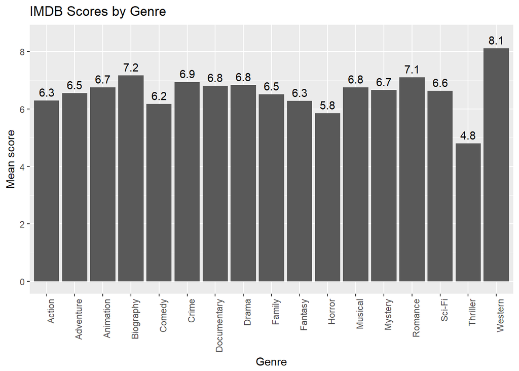

```r
final_data %>%
  # Isolate the first genre of each list to retrieve the main genre
  mutate(main_genre = sub("\\|.*", "", genres)) %>%
  group_by(main_genre) %>%
  # Calculate the mean score of each genre
  summarise(mean_score = mean(imdb_score)) %>%
  ggplot(aes(x=main_genre,y=mean_score)) +
    # Graph the bars of each genre
    geom_bar(stat="identity") +
    # Rotate the bottom labels
    theme(axis.text.x = element_text(angle = 90, hjust = 1)) +
    ylim(0,8.5) +
    # Add the ratings to the top of each bar
    geom_text(aes(label=round(mean_score,1)),vjust=-0.5) +
    labs(title="IMDB Scores by Genre",
      x = "Genre",
      y = "Mean score")
```

This is very interesting - Western films seem to outrank all other genres by a hefty margin. Thrillers also seem to fare much worse on the scale than any other genre. One could suspect that filtering out one genre from a movie might not be an ideal method to distinguish movies. Further effort could be done into achieving more accurate results.

# Hypothesis Testing and Machine Learning

Let’s start to physically compute some trends and get our machine to learn how to predict movie ratings. We’ll start with a couple linear regression models, which allow us to create a linear function based on a couple predictors we give it. To learn more about lm models you can see: http://stat.ethz.ch/R-manual/R-devel/library/stats/html/lm.html

# Hypothesis Testing

We’ll start by looking at two unrelated factors: duration, and facenumber. We need to be careful about picking our predictors because if they are at all related to each other, it may upset the linearity of our model. Even though facenumber we saw did not prove to have much correlation, it’ll be useful in contrasting it with other predictors.

```r
# Fit an lm model on duration and facenumber
fit <- lm(imdb_score~1+duration+facenumber_in_poster,data=final_data)
fit %>% tidy()
```

```
##                   term    estimate    std.error statistic       p.value
## 1          (Intercept)  4.62644772 0.0799669728 57.854481  0.000000e+00
## 2             duration  0.01715325 0.0007065858 24.276241 4.896743e-121
## 3 facenumber_in_poster -0.03871714 0.0078377242 -4.939845  8.159806e-07
```

Our null hypothesis, as with establishing any relationship, is that *no* relationship can be seen between our scores and predictors.  
Interestingly, from our data collected, the increasing number of faces on average lowers the score by about 0.0.4 per face. Cluttered posters may have a negative outcome on movie reception, it seems. Duration also has a fairly significant trend - the longer the movie, the higher the rating. These two predictors also have p-values significantly small, meaning we can *reject* our null hypothesis that there is no relationship, and conclude that these factors indeed have an impact on score.  
Let’s also take a look at the anova function. This will spit out an F-value, which basically tells us how significant of a relationship there is between the values and predictors. If it is larger enough than 1, we can conclude that it is significant.

```r
anova(fit)
```

```
## Analysis of Variance Table
##
## Response: imdb_score
##                        Df Sum Sq Mean Sq F value    Pr(>F)
## duration                1  560.0  560.04 583.236 < 2.2e-16 ***
## facenumber_in_poster    1   23.4   23.43  24.402  8.16e-07 ***
## Residuals            3749 3599.9    0.96
## ---
## Signif. codes:  0 '***' 0.001 '**' 0.01 '*' 0.05 '.' 0.1 ' ' 1
```

Our two factors indeed produce F values larger than 1, and we can see that score is very much dependent on the duration of the movie, which is an especially significant trend.  
Now, we’ll also do another separate lm model for budget. We’ll compute the same values we did for the previous model.

```r
fit_2 <- lm(imdb_score~std_budget,data=final_data)
fit_2 %>% tidy()
```

```
##          term   estimate  std.error  statistic     p.value
## 1 (Intercept) 6.46035819 0.01723137 374.918380 0.000000000
## 2  std_budget 0.04522829 0.01723368   2.624413 0.008715144
```

```r
anova(fit_2)
```

```
## Analysis of Variance Table
##
## Response: imdb_score
##              Df Sum Sq Mean Sq F value   Pr(>F)
## std_budget    1    7.7  7.6505  6.8875 0.008715 **
## Residuals  3739 4153.2  1.1108
## ---
## Signif. codes:  0 '***' 0.001 '**' 0.01 '*' 0.05 '.' 0.1 ' ' 1
```

We can see that on average, keeping all other parameters constant, the standardized budget increases score by about 0.045. While this may seem like a larger significance than duration, keep in mind this is only one predictor we have used, and the inclusion of more factors would indeed truncate the effectiveness of only one predictor. We still get a p-value which is very small, meaning we can reject our null hypothesis that budget doesn’t play a role in determining score. Our p-value indicates that the chances there is no relationship is very very small.  
Looking at our F-value, we can see that we also get a value that is greater than 1. This helps to confirm the role that budget playes in predicting score.

# Machine Learning

Finally, let’s use our machine to learn about our data, and use it to then predict various score of random movies. We’re going to split the data up into testing and training, so that we can use half to learn and the other half to compare our predictions.

```r
#Two halves of the set: train for use in the random forest, and test for use with prediction
train <-final_data[1:1867,] %>% na.omit()
test <- final_data[1877:3752,] %>% na.omit()
```

I am using the *random forest* algorithm to carry out the learning process. The random forest produces decision trees which compile an overall estimate of the score based on the results of each individual tree. More can be learned about this method here: https://cran.r-project.org/web/packages/randomForest/randomForest.pdf  
I am using a bunch of interesting predictors that I thought would be interesting to see their roles in the prediction process.

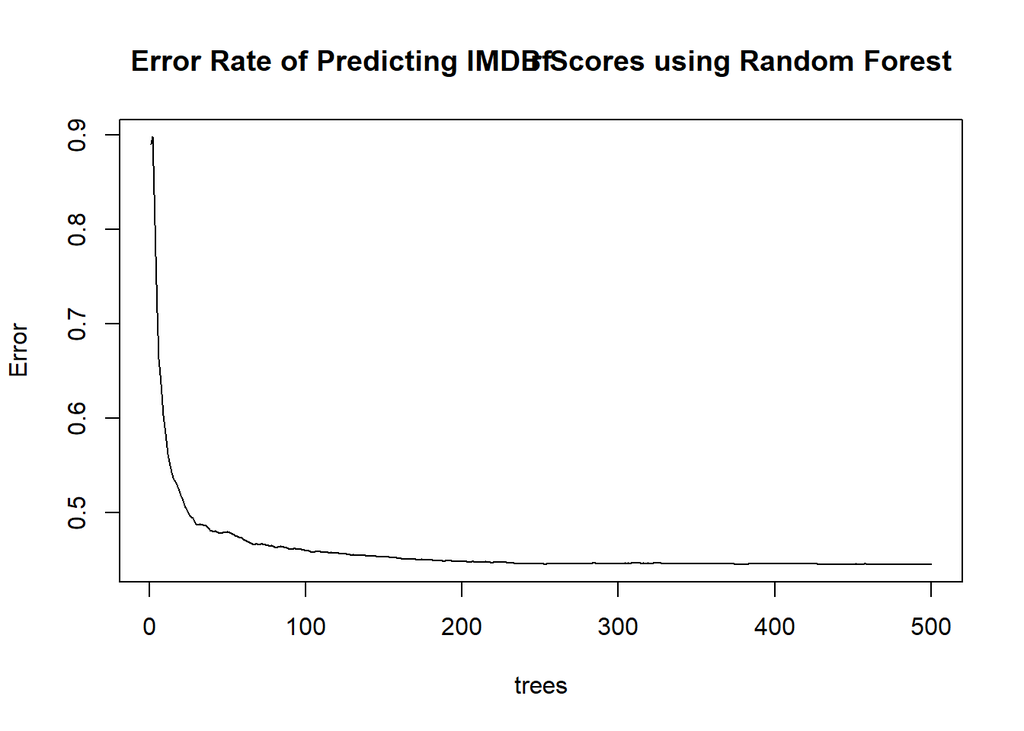

```r
set.seed(1234)

# Compute the random forest, with a variety of predictors
rf <- randomForest(imdb_score~std_budget+duration+num_voted_users+cast_total_facebook_likes+
                     facenumber_in_poster+movie_facebook_likes+std_gross,data=train)

plot(rf)
title("Error Rate of Predicting IMDB Scores using Random Forest")
```

We’ll now look at the importance of each predictor as it was used in the machine learning. I created a bar graph to represent how each one fares against one another.

```r
# Calculate the importance
importance <- importance(rf)
# Construct a data frame for the importance factors
df <- data_frame(predictors = row.names(importance), Importance=round(importance[,]))
df
```

```
## # A tibble: 7 x 2
##   predictors                Importance
##   <chr>                          <dbl>
## 1 std_budget                     175
## 2 duration                       362
## 3 num_voted_users                561
## 4 cast_total_facebook_likes      176
## 5 facenumber_in_poster            52.0
## 6 movie_facebook_likes           205
## 7 std_gross                      211
```

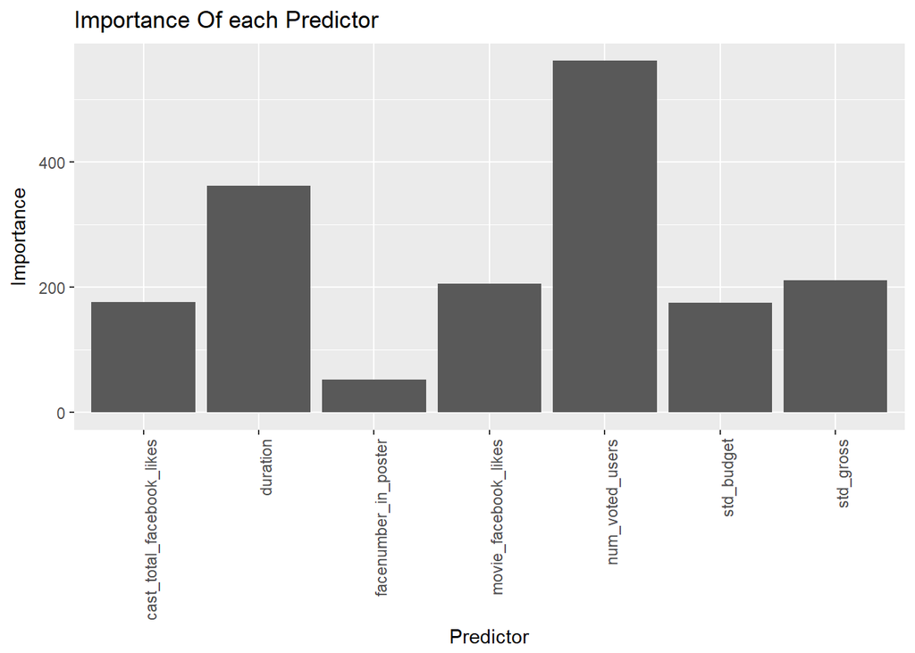

```r
ggplot(df,aes(x=predictors,y=Importance))+
  geom_bar(stat="identity") +
  theme(axis.text.x = element_text(angle = 90, hjust = 1)) +
  labs(title="Importance Of each Predictor",
    x = "Predictor",
    y = "Importance")
```

As seen previously, facenumber indeed does not play a huge role in the criteria for gauging IMDB score. In fact, duration and the number of users voting are what play the largest roles. Unfortunately, the number of IMDB votes doesn’t pertain to the actual movie, but this provides great insight as to how these scores come about. Since many user tend to vote similarily, more users means the score will tend towards a more predictable value, which is most likely why this comes in handy so much.

Finally, let’s look at the prediction rates with the other half of the data; I have constructed a scatter plot of the *mean square error* of our predicted vs actual values.

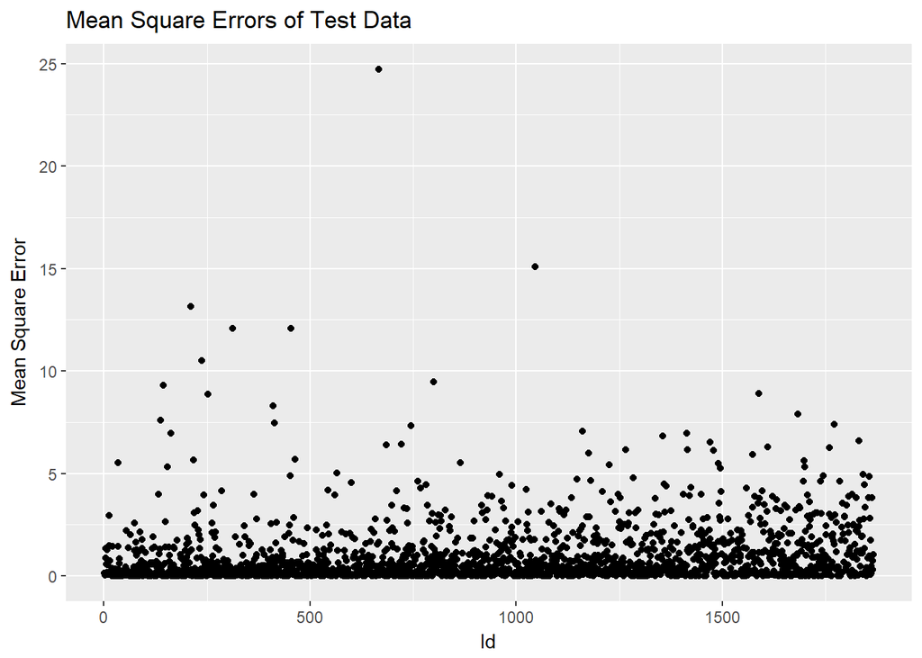

```r
# Conduct the prediction
prediction <- predict(rf, test) %>%
  data_frame() %>%
  # Add a ID number to sync predictions with actual data
  rowid_to_column("id")
test %>%
  mutate(id = seq.int(nrow(test))) %>%
  # Add predictions to test
  left_join(prediction,by="id") %>%
  # Compute the MSA
  mutate(mse = (imdb_score - .)^2) %>%
  ggplot(aes(x=id,y=mse)) +
    geom_point() +
    labs(title="Mean Square Errors of Test Data",
      x = "Id",
      y = "Mean Square Error")
```

Most of the error rates range very close to 0, which is a great distribution.

# Conclusion

We collected many different factors that helped us to determine the best possible prediction for our IMDB scores. We saw that many of them didn’t quite create a noticeable trend in the data, but other fare very well, especially considering how users tend to vote very similarily and the data set was so large. Factors outside the movie, such as the number of IMDB votes, played very significant roles in predicting scores, which intuitively makes sense. Other movie data, such as duration and budget, we saw indeed had roles which one would expect these to have. overall, there is much that can be done in analyzing this dataset, and I’ve only scratched the surface of the trends and findings available with the movies.